# lesson3

Sumit Kant

5 September 2016

# Psuedo Facebook Data

THe goal here is to understand user behaviour and demographics of the facebook users. This data is similar to what data scientist at facebook use on a daily basis.

# Reading in Data

```r
getwd()
```

```
## [1] "D:/IIML/Crisp Analytics/Udacity/DAta analysis with R"
```

```r
list.files()
```

```
## [1] "lesson3.html"        "lesson3.rmd"         "lesson3_student.rmd"
## [4] "pseudo_facebook.tsv" "reddit.csv"          "reddit.R"
## [7] "stateData.csv"       "stateData.R"
```

```r
setwd('D:/IIML/Crisp Analytics/Udacity/DAta analysis with R/')
```

## loading a tab separated file

```r
pf <- read.csv('pseudo_facebook.tsv', sep="\t")
# To check out the variable names
names(pf)
```

```
##  [1] "userid"                "age"
##  [3] "dob_day"               "dob_year"
##  [5] "dob_month"             "gender"
##  [7] "tenure"                "friend_count"
##  [9] "friendships_initiated" "likes"
## [11] "likes_received"        "mobile_likes"
## [13] "mobile_likes_received" "www_likes"
## [15] "www_likes_received"
```

## Histogram of users’ Birthdays

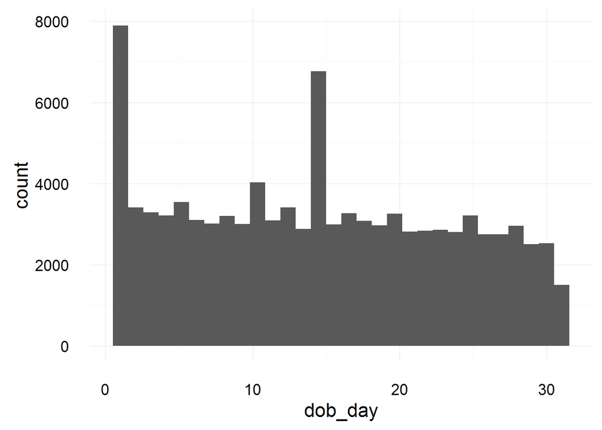

```r
library(ggplot2)
theme_set(theme_minimal(16))

qplot(x = dob_day, data=pf)
```

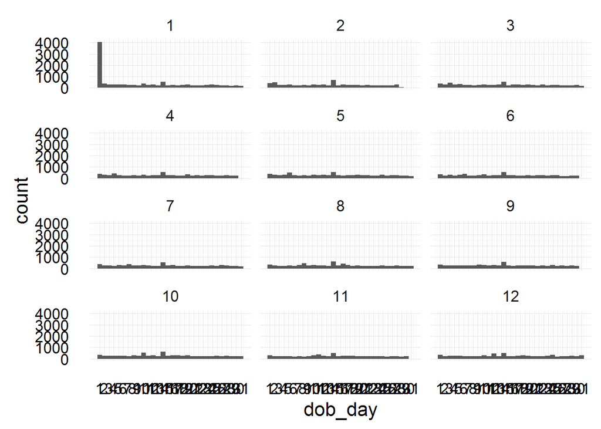

```r
qplot(x = dob_day, data=pf) +
  scale_x_continuous( breaks = 1:31) +
  facet_wrap(~dob_month, ncol=3)
```

facet_wrap allows plotting graphs along one variable and visualize the difference across other variables facet_grid is similar to facet_wrap as it can take two variables instead of one as an input

## Friend Count

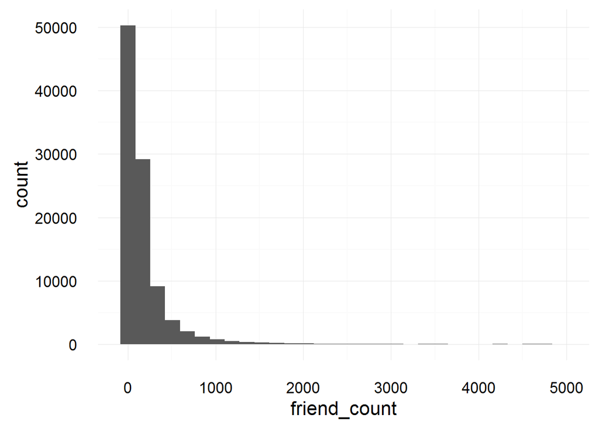

```r
qplot(friend_count, data = pf) + geom_histogram()
```

This data is positively skewed and is called long tailed data. The number of facebook friends a user has are less than 500 for most of the data.

### To limit the axes using xlim parameter

xlim uses starting point and ending point to wrap the data.

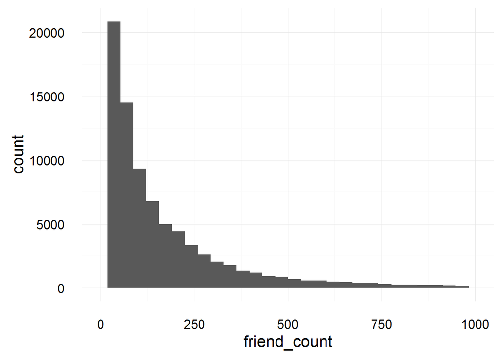

```r
qplot(friend_count, data = pf, xlim = c(0,1000))
```

Alternatively, we can also use scale_x_continuous to limit the data.

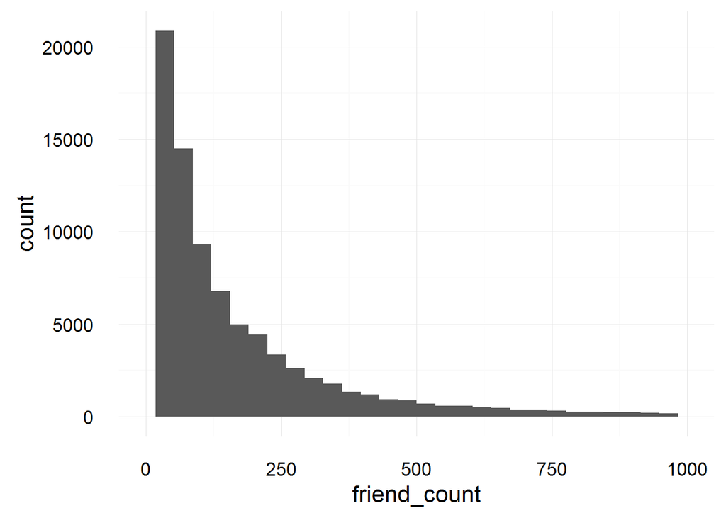

```r
qplot(friend_count, data = pf) +
  scale_x_continuous(limits = c(0,1000))
```

This allows us to make the plots in layers

## Adjusting the bin widthi

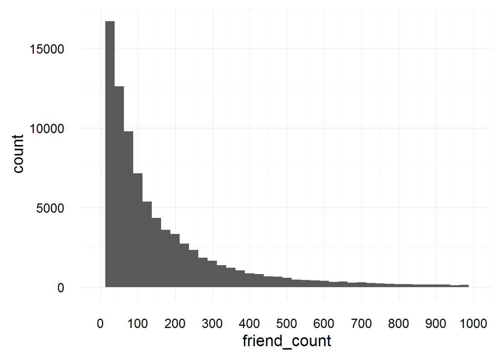

```r
qplot(friend_count, data = pf, binwidth = 25) +
  scale_x_continuous(limits = c(0,1000), breaks = seq(0,1000,100))
```

## Question: Which gender group has more friends, men or women? TO answer this we need to split the histogram into two parts Once again we can use facet_wrap and wrap by variable ‘gender’

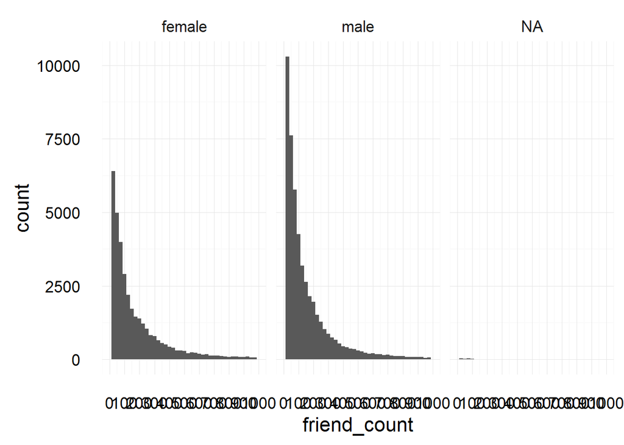

```r
qplot(friend_count, data = pf, binwidth = 25) +
  scale_x_continuous(limits = c(0,1000), breaks = seq(0,1000,100)) +
  facet_wrap(~gender)
```

*Problem*

Also plotting NA values in the gender.

*SOlution*

Subset the data and remove NA values

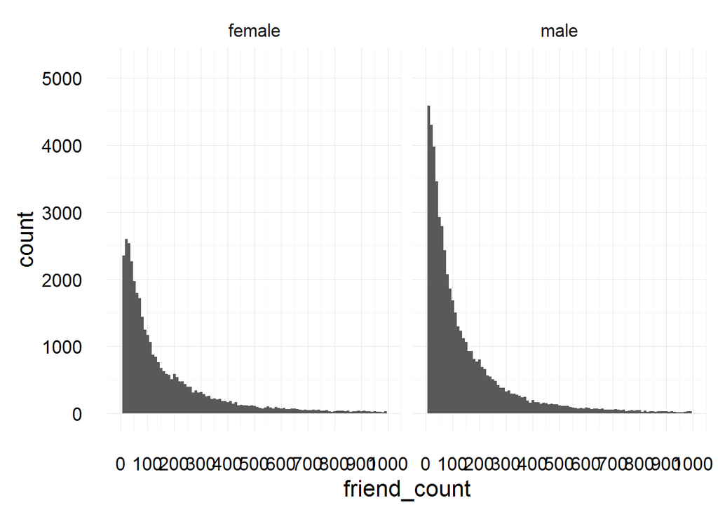

```r
qplot(friend_count, data = subset(pf, !(is.na(gender))), binwidth = 10) +
  scale_x_continuous(limits = c(0,1000), breaks = seq(0,1000,100)) +
  facet_wrap(~gender)
```

## Statistics by ‘Gender’

```r
table(pf$gender)
```

```
##
## female   male
##  40254  58574
```

```r
by(pf$friend_count, pf$gender, summary)
```

```
## pf$gender: female
##    Min. 1st Qu.  Median    Mean 3rd Qu.    Max.
##       0      37      96     242     244    4923
## --------------------------------------------------------
## pf$gender: male
##    Min. 1st Qu.  Median    Mean 3rd Qu.    Max.
##       0      27      74     165     182    4917
```

Gives the summary statisics based on gender. The median is higher for females and the difference is 22. Also, the mean is greater for females than males

## Tenure

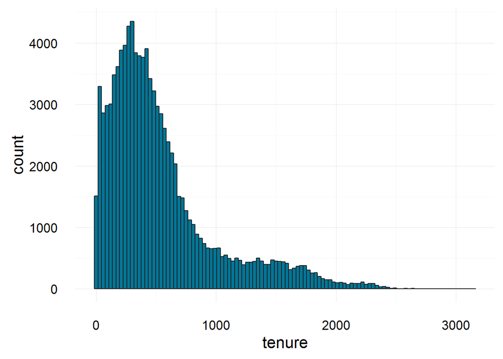

```r
qplot(x = tenure, data = pf, binwidth = 30, color = I('#1e1d1d'), fill=I('#047697'))
```

*Tenure in Years*

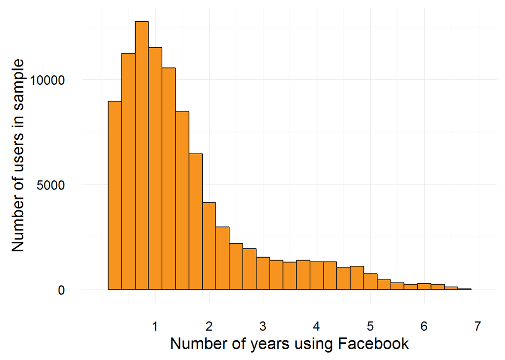

```r
qplot(x = tenure/365, data = pf, binwidth = 0.25, color = I('#1e1d1d'), fill=I('#F79420')) +
  scale_x_continuous(breaks = seq(1,7,1), limits = c(0,7)) +
  xlab('Number of years using Facebook') +
  ylab('Number of users in sample')
```

## User ages Histogram of users based on their age

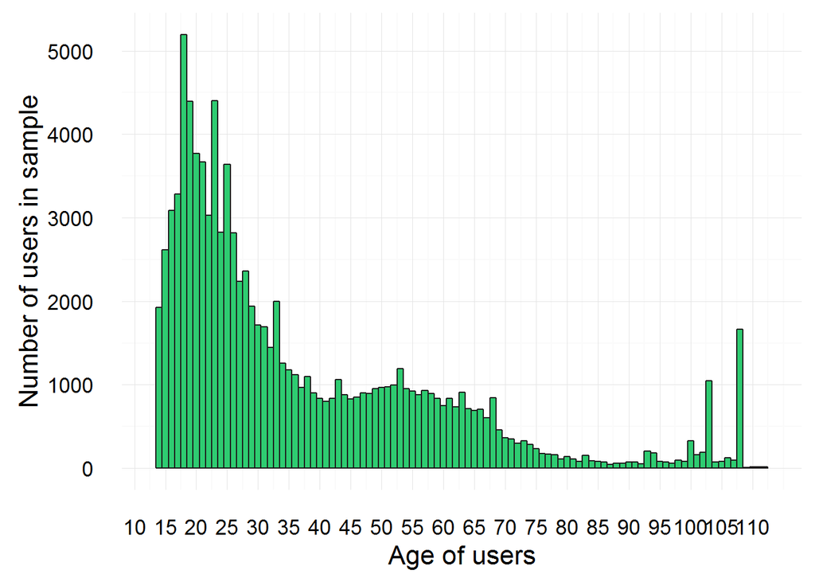

```r
qplot(x = age, data = pf, binwidth = 1, color = I('#1e1d1d'), fill=I('#2ecc71')) +
  scale_x_continuous(breaks = seq(10,max(pf$age),5), limits = c(min(pf$age),max(pf$age))) +
  xlab('Age of users') +
  ylab('Number of users in sample')
```

## Transforming data

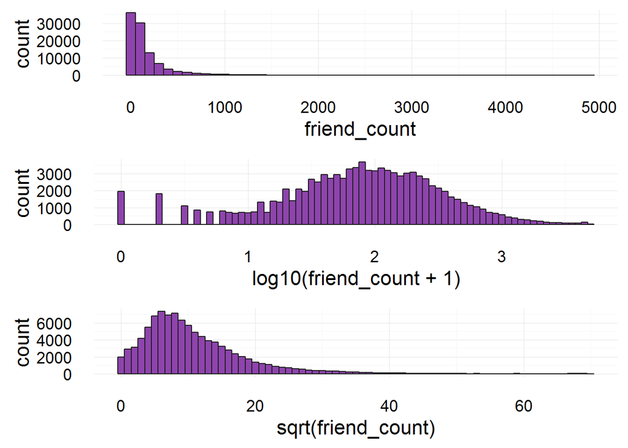

```r
library(gridExtra)
p1 <- qplot(x = friend_count, data = pf, binwidth = 100, color = I('#1e1d1d'), fill=I('#8e44ad'))
p2 <- qplot(x = log10(friend_count+1), data = pf, binwidth = 0.05, color = I('#1e1d1d'), fill=I('#8e44ad'))
p3 <- qplot(x = sqrt(friend_count), data = pf, binwidth = 1, color = I('#1e1d1d'), fill=I('#8e44ad'))
grid.arrange(p1,p2,p3)
```